# Autogenous - FST estimates

Luciano V Cosme

2024-08-15

## Libraries

```r
library(StAMPP)
library(ggplot2)
library(tidyverse)
library(colorout)
library(here)
library(reshape2)
library(dplyr)
library(tidyr)
library(dartR)
library(Cairo)
library(data.table)
library(scales)
```

We can use different data sets to run our fst estimates.

Clean env and memory

```r
# Remove all objects from the environment
rm(list = ls())

# Run the garbage collector to free up memory
gc()
```

```
##           used  (Mb) gc trigger  (Mb) limit (Mb) max used  (Mb)
## Ncells 5777152 308.6    9698345 518.0         NA  7056962 376.9
## Vcells 9515431  72.6   14991442 114.4      32768 12396749  94.6
```

## 1. Estimate pairwise FST for all populations

We can convert to raw format

```bash
plink \
--keep-allele-order \
--bfile output/ldna/files/file1 \
--recodeA \
--out output/fst/pop_pairwise \
--silent;
grep 'samples\|variants\|remaining' output/fst/pop_pairwise.log
```

```
## 110353 variants loaded from .bim file.
## 110353 variants and 60 people pass filters and QC.
## Among remaining phenotypes, 28 are cases and 22 are controls.  (10 phenotypes
```

Look at https://rdrr.io/cran/StAMPP/man/stamppFst.html for details of Fst estimations

```r
pop_pairwise <-
  read.PLINK(
    here(
      "output", "fst", "pop_pairwise.raw"
    ),
    quiet = FALSE,
    chunkSize = 1000,
    parallel = require("parallel"),
    n.cores = 4
  )

summary(pop_pairwise)
```

Now lets convert the genlight object to Stampp format, and estimate pairwise Fst values

The command below would also work, but you can simplify it and put only the numbers: pop_pairwise2 <- stamppFst(pop_pairwise, nboots=10, percent=95 + nclusters=8)

This chunk will take a couple minutes to run.

```r
# Convert
pop_pairwise2 <- stamppConvert(pop_pairwise, type="genlight")

# I am runing with 10 bootstraps, using 95% percentile to calculate confidence intervals, and 8 threads
pop_pairwise2 <- stamppFst(pop_pairwise2, 10, 95, 8)
```

Save it, so we do not have to run it again

```r
saveRDS(
  pop_pairwise2, here(
    "output", "fst", "pop_pairwise2.rds"
  )
)
```

To load it

```r
pop_pairwise2 <- readRDS(
  here(
    "output", "fst", "pop_pairwise2.rds"
  )
)
```

Now lets look at the object

```r
summary(pop_pairwise2)
```

```
##            Length Class      Mode
## Fsts        9     -none-     numeric
## Pvalues     9     -none-     numeric
## Bootstraps 16     data.frame list
```

If you want you can save the fst values as csv.

```r
# Convert to data frame
pop_pairwise2_df <- data.frame(pop_pairwise2)

# Save it
write.csv(pop_pairwise2_df, file = here("output", "fst", "pop_pairwise2_df.csv"))
```

Check the Fst values

```r
pop_pairwise2_df
```

```
##       Fsts.MAN  Fsts.AUT Fsts.NEW Pvalues.MAN Pvalues.AUT Pvalues.NEW
## MAN         NA        NA       NA          NA          NA          NA
## AUT 0.12987132        NA       NA           0          NA          NA
## NEW 0.04311201 0.1273737       NA           0           0          NA
##     Bootstraps.Population1 Bootstraps.Population2 Bootstraps.1 Bootstraps.2
## MAN                    MAN                    AUT   0.12885655   0.12893077
## AUT                    MAN                    NEW   0.04239546   0.04264869
## NEW                    AUT                    NEW   0.12617486   0.12653023
##     Bootstraps.3 Bootstraps.4 Bootstraps.5 Bootstraps.6 Bootstraps.7
## MAN   0.12895214   0.12896490   0.12944684   0.12957274   0.12973788
## AUT   0.04269079   0.04282072   0.04293521   0.04296295   0.04315717
## NEW   0.12693714   0.12694415   0.12711393   0.12733918   0.12753014
##     Bootstraps.8 Bootstraps.9 Bootstraps.10 Bootstraps.Lower.bound.CI.limit
## MAN   0.12995225   0.13000080    0.13000233                      0.12885655
## AUT   0.04323748   0.04324661    0.04346749                      0.04239546
## NEW   0.12753423   0.12759138    0.12762343                      0.12617486
##     Bootstraps.Upper.bound.CI.limit Bootstraps.p.value Bootstraps.Fst
## MAN                      0.13000080                  0     0.12987132
## AUT                      0.04324661                  0     0.04311201
## NEW                      0.12759138                  0     0.12737374
```

We can subset the object

```r
# Create an object for columns with 'Fsts.'
fst_columns <- grep("Fsts\\.", names(pop_pairwise2_df), value = TRUE)
fst_df <- pop_pairwise2_df[, fst_columns]

# Create an object for columns with 'Pvalues.'
pvalue_columns <- grep("Pvalues\\.", names(pop_pairwise2_df), value = TRUE)
pvalue_df <- pop_pairwise2_df[, pvalue_columns]

# You can view the first few rows of these dataframes to confirm
head(fst_df)
```

```
##       Fsts.MAN  Fsts.AUT Fsts.NEW
## MAN         NA        NA       NA
## AUT 0.12987132        NA       NA
## NEW 0.04311201 0.1273737       NA
```

```r
head(pvalue_df)
```

```
##     Pvalues.MAN Pvalues.AUT Pvalues.NEW
## MAN          NA          NA          NA
## AUT           0          NA          NA
## NEW           0           0          NA
```

All the p-values are zero, indicating statistical significance

We will convert the data into a matrix.

```r
# First we can rename the columns of the fst values object
# Use gsub to remove 'Fsts.' from the column names
names(fst_df) <- gsub("Fsts\\.", "", names(fst_df))

# Create matrix
aa <- as.matrix(fst_df)
aa[upper.tri(aa)] <- t(aa)[upper.tri(t(aa))]
head(aa)
```

```
##            MAN       AUT        NEW
## MAN         NA 0.1298713 0.04311201
## AUT 0.12987132        NA 0.12737374
## NEW 0.04311201 0.1273737         NA
```

Lets check if the matrix is symmetric.

```r
isSymmetric(aa)
```

```
## [1] TRUE
```

We will also add NA on the upper left side of the matrix.

```r
aa[lower.tri(aa)] <- NA
```

Now we have to convert the matrix to a data frame to plot it with ggplot.

```r
pairfst.long <- melt(aa)
summary(pairfst.long)
```

```
##   Var1    Var2       value
##  MAN:3   MAN:3   Min.   :0.04311
##  AUT:3   AUT:3   1st Qu.:0.08524
##  NEW:3   NEW:3   Median :0.12737
##                  Mean   :0.10012
##                  3rd Qu.:0.12862
##                  Max.   :0.12987
##                  NA's   :6
```

Now lets plot the data with ggplot. You can click in the little square on the top left of the plot to open it on a new window. It will have the right proportions.

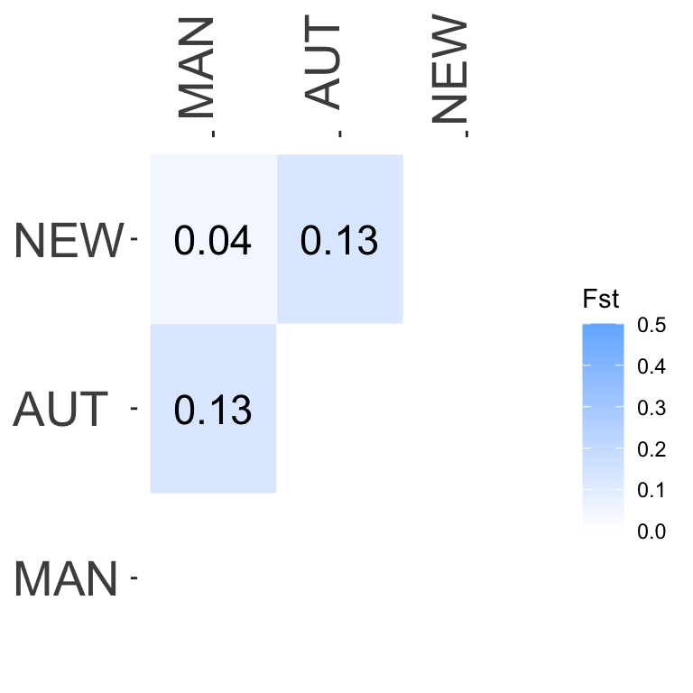

```r
pairfst.f <- ggplot(pairfst.long, aes(Var1, Var2)) +
  geom_tile(aes(fill = value), colour = "white") +
  scale_fill_gradient(
    low = "white",
    high = "#71b6ff",
    name = "Fst",
    na.value = "white",
    limits = c(0, 0.5)
  ) +
  scale_x_discrete(position = "top") +
  theme_bw() +
  geom_text(aes(label = ifelse(
    is.na(value), "", formatC(value, digits = 2, format = "f")
  )), size = 6) +
  theme(
    axis.text.x = element_text(angle = 90, hjust = 1, size = 20),
    axis.title = element_blank(),
    panel.grid.major = element_blank(),
    panel.grid.minor = element_blank(),
    panel.border = element_blank(),
    panel.background = element_blank(),
    axis.text.y = element_text(hjust = 0, size = 20)
  )
pairfst.f
```

While the Fst between the wild populations, NEW and MAN, is 0.04, the values between them the the autogenous is 0.13.

```r
output_path <- here("output", "fst", "figures", "pairwise_estimates.pdf")
ggsave(output_path, pairfst.f, height = 4, width = 4, dpi = 300)
```

## 2. Estimate Fst between males and females

We do not have sex information for mosquitoes of MAN, but we do have it for NEW and AUT

We can import the fam file to identify males and females

```r
# Specify the path using the 'here' function
fam_file_path <- here("output", "ldna", "files", "file1.fam")

# Now, read the file using the path - using data.table library
fam_data <- fread(fam_file_path, header = FALSE)

# Rename columns for clarity
setnames(fam_data, c("FID", "IID", "PID", "MID", "Sex", "Phenotype"))

head(fam_data)
```

```
##    FID IID PID MID Sex Phenotype
## 1: MAN 306   0   0   0        -9
## 2: MAN 307   0   0   0        -9
## 3: MAN 308   0   0   0        -9
## 4: MAN 309   0   0   0        -9
## 5: MAN 310   0   0   0        -9
## 6: MAN 311   0   0   0        -9
```

Separate males and females per population

```r
# Create a list of data frames, each representing a different FID
fam_list <- split(fam_data, fam_data$FID)

# Initialize lists to store male and female data separately for each FID
males_per_fid <- list()
females_per_fid <- list()

# Loop through each FID and subset males and females
for(fid in names(fam_list)) {
    males_per_fid[[fid]] <- fam_list[[fid]][Sex == 1, ]
    females_per_fid[[fid]] <- fam_list[[fid]][Sex == 2, ]
}
```

Now we can save a list of mosquitoes for which we know the sex information

```r
# Combine male and female data into one data frame
combined_data <- rbindlist(c(males_per_fid, females_per_fid), use.names = TRUE, fill = TRUE)

# Select only the FID and IID columns
plink_data <- combined_data[, .(FID, IID)]

# Export the combined data to a text file
fwrite(plink_data, file = here("output", "fst", "male_female.txt"), sep = "\t", quote = FALSE)
```

Now we can subset the data

```bash
plink \
--keep-allele-order \
--bfile output/ldna/files/file1 \
--keep output/fst/male_female.txt \
--out output/fst/new_aut \
--make-bed \
--silent;
grep 'samples\|variants\|remaining' output/fst/new_aut.log
```

```
## 110353 variants loaded from .bim file.
## --keep: 50 people remaining.
## Total genotyping rate in remaining samples is 0.976527.
## 110353 variants and 50 people pass filters and QC.
## Among remaining phenotypes, 28 are cases and 22 are controls.
```

We can import the fam file to identify males and females

```r
# Specify the path using the 'here' function
fam_file_path <- here("output", "fst", "new_aut.fam")

# Now, read the file using the path - using data.table library
fam_data2 <- fread(fam_file_path, header = FALSE)

# Rename columns for clarity
setnames(fam_data2, c("FID", "IID", "PID", "MID", "Sex", "Phenotype"))

head(fam_data2)
```

```
##    FID IID PID MID Sex Phenotype
## 1: AUT 384   0   0   1         2
## 2: AUT 385   0   0   1         2
## 3: AUT 386   0   0   1         2
## 4: AUT 387   0   0   1         2
## 5: AUT 388   0   0   1         2
## 6: AUT 389   0   0   1         2
```

Now we can change the FID to separate the males and females for each population, so we end up with 4 groups of mosquitoes

```r
# Add the suffix '_M' or '_F' to the IID column based on the Sex column
fam_data2$FID <-
  ifelse(
    fam_data2$Sex == 1,
    paste0(fam_data2$FID, "_M"),
    ifelse(fam_data2$Sex == 2, paste0(fam_data2$FID, "_F"), fam_data2$FID)
  )

# Now you can check the first few rows to confirm the change
head(fam_data2)
```

```
##      FID IID PID MID Sex Phenotype
## 1: AUT_M 384   0   0   1         2
## 2: AUT_M 385   0   0   1         2
## 3: AUT_M 386   0   0   1         2
## 4: AUT_M 387   0   0   1         2
## 5: AUT_M 388   0   0   1         2
## 6: AUT_M 389   0   0   1         2
```

Now we can save the file and replace the original .fam file

```r
# Save the modified dataframe to a text file
fwrite(fam_data2, file = here("output", "fst", "new_aut.fam"), sep = "\t", quote = FALSE, col.names = FALSE)
```

Check it

```bash
head output/fst/new_aut.fam
```

```
## AUT_M    384 0   0   1   2
## AUT_M    385 0   0   1   2
## AUT_M    386 0   0   1   2
## AUT_M    387 0   0   1   2
## AUT_M    388 0   0   1   2
## AUT_M    389 0   0   1   2
## AUT_M    390 0   0   1   2
## AUT_M    391 0   0   1   2
## AUT_M    392 0   0   1   2
## AUT_M    393 0   0   1   2
```

Now we can convert it to raw format and repeat the fst estimates

We can convert to raw format

```bash
# For consistance we need to use the same thresholds we used to create the file with the 3 populations. So, we set genotype missingness to 20% and MAF to 5%
plink \
--keep-allele-order \
--bfile output/fst/new_aut \
--recodeA \
--geno 0.2 \
--maf 0.05 \
--out output/fst/sex \
--silent;
grep 'samples\|variants\|remaining' output/fst/sex.log
```

```
## 110353 variants loaded from .bim file.
## 357 variants removed due to missing genotype data (--geno).
## 12221 variants removed due to minor allele threshold(s)
## 97775 variants and 50 people pass filters and QC.
## Among remaining phenotypes, 28 are cases and 22 are controls.
```

Clean env and memory

```r
# Remove all objects from the environment
rm(list = ls())

# Run the garbage collector to free up memory
gc()
```

```
##            used  (Mb) gc trigger  (Mb) limit (Mb) max used  (Mb)
## Ncells  5985627 319.7    9700114 518.1         NA  7987193 426.6
## Vcells 10053743  76.8   14995962 114.5      32768 12429959  94.9
```

```r
sex_pairwise <-
  read.PLINK(
    here(
      "output", "fst", "sex.raw"
    ),
    quiet = FALSE,
    chunkSize = 1000,
    parallel = require("parallel"),
    n.cores = 4
  )

summary(sex_pairwise)
```

Now lets convert the genlight object to Stampp format, and estimate pairwise Fst values

The command below would also work, but you can simplify it and put only the numbers: pop_pairwise2 <- stamppFst(pop_pairwise, nboots=10, percent=95 + nclusters=8)

This chunk will take a couple minutes to run.

```r
# Convert
sex_pairwise2 <- stamppConvert(sex_pairwise, type="genlight")

# I am runing with 10 bootstraps, using 95% percentile to calculate confidence intervals, and 8 threads
sex_pairwise2 <- stamppFst(sex_pairwise2, 10, 95, 8)
```

Save it, so we do not have to run it again

```r
saveRDS(
  sex_pairwise2, here(
    "output", "fst", "sex_pairwise2.rds"
  )
)
```

To load it

```r
sex_pairwise2 <- readRDS(
  here(
    "output", "fst", "sex_pairwise2.rds"
  )
)
```

Now lets look at the object

```r
summary(sex_pairwise2)
```

```
##            Length Class      Mode
## Fsts       16     -none-     numeric
## Pvalues    16     -none-     numeric
## Bootstraps 16     data.frame list
```

If you want you can save the fst values as csv.

```r
# Convert the 'Fsts' and 'Pvalues' matrices to dataframes
fsts_df <- as.data.frame(sex_pairwise2$Fsts)
pvalues_df <- as.data.frame(sex_pairwise2$Pvalues)

head(fsts_df)
```

```
##            AUT_M     AUT_F      NEW_M NEW_F
## AUT_M         NA        NA         NA    NA
## AUT_F 0.03971471        NA         NA    NA
## NEW_M 0.16839622 0.1541147         NA    NA
## NEW_F 0.13607526 0.1224449 0.03188417    NA
```

```r
# Save it
write.csv(fsts_df, file = here("output", "fst", "sex_pairwise2_df.csv"))
```

Check the p-values

```r
head(pvalues_df)
```

```
##       AUT_M AUT_F NEW_M NEW_F
## AUT_M    NA    NA    NA    NA
## AUT_F     0    NA    NA    NA
## NEW_M     0     0    NA    NA
## NEW_F     0     0     0    NA
```

All the p-values are zero, indicating statistical significance

We will convert the data into a matrix.

```r
# First we can rename the columns of the fst values object
# Use gsub to remove 'Fsts.' from the column names
names(fsts_df) <- gsub("Fsts\\.", "", names(fsts_df))

# Create matrix
aa <- as.matrix(fsts_df)
aa[upper.tri(aa)] <- t(aa)[upper.tri(t(aa))]
head(aa)
```

```
##            AUT_M      AUT_F      NEW_M      NEW_F
## AUT_M         NA 0.03971471 0.16839622 0.13607526
## AUT_F 0.03971471         NA 0.15411469 0.12244490
## NEW_M 0.16839622 0.15411469         NA 0.03188417
## NEW_F 0.13607526 0.12244490 0.03188417         NA
```

Lets check if the matrix is symmetric.

```r
isSymmetric(aa)
```

```
## [1] TRUE
```

We will also add NA on the upper left side of the matrix.

```r
aa[lower.tri(aa)] <- NA
```

Now we have to convert the matrix to a data frame to plot it with ggplot.

```r
pairfst.long <- reshape2::melt(aa)
summary(pairfst.long)
```

```
##     Var1      Var2       value
##  AUT_M:4   AUT_M:4   Min.   :0.03188
##  AUT_F:4   AUT_F:4   1st Qu.:0.06040
##  NEW_M:4   NEW_M:4   Median :0.12926
##  NEW_F:4   NEW_F:4   Mean   :0.10877
##                      3rd Qu.:0.14960
##                      Max.   :0.16840
##                      NA's   :10
```

Now lets plot the data with ggplot. You can click in the little square on the top left of the plot to open it on a new window. It will have the right proportions.

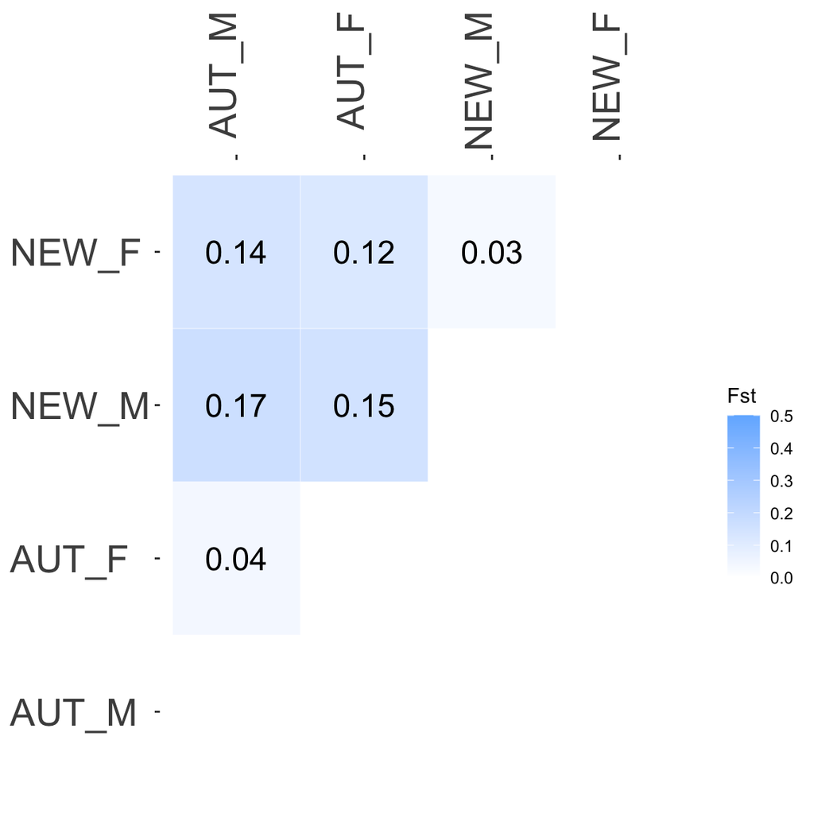

```r
pairfst.f <- ggplot(pairfst.long, aes(Var1, Var2)) +
  geom_tile(aes(fill = value), colour = "white") +
  scale_fill_gradient(
    low = "white",
    high = "#71b6ff",
    name = "Fst",
    na.value = "white",
    limits = c(0, 0.5)
  ) +
  scale_x_discrete(position = "top") +
  theme_bw() +
  geom_text(aes(label = ifelse(
    is.na(value), "", formatC(value, digits = 2, format = "f")
  )), size = 6) +
  theme(
    axis.text.x = element_text(angle = 90, hjust = 1, size = 20),
    axis.title = element_blank(),
    panel.grid.major = element_blank(),
    panel.grid.minor = element_blank(),
    panel.border = element_blank(),
    panel.background = element_blank(),
    axis.text.y = element_text(hjust = 0, size = 20)
  )
pairfst.f
```

The highest differentiation is between the males across population. For example, NEW males and AUT males have an Fst value of 0.17 while the females have 0.12. The differences within sex is low, 0.04 for AUT and 0.03 for NEW. The Fst estimates for females between the populations is lower than males, for females of AUT and NEW the Fst value is 0.12, while between males is 0.17. Now, between sex, for AUT males vs NEW females the fst value is 0.14, while AUT females vs NEW males is 0.15, which are quite similar.

```r
output_path <- here("output", "fst", "figures", "sex_estimates.pdf")
ggsave(output_path, pairfst.f, height = 6, width = 6, dpi = 300)
```

## 3. Sliding windows Fst estimates between the populations

Clean env and memory

```r
# Remove all objects from the environment
rm(list = ls())

# Run the garbage collector to free up memory
gc()
```

```
##           used  (Mb) gc trigger  (Mb) limit (Mb) max used  (Mb)
## Ncells 5985765 319.7    9700114 518.1         NA  8795592 469.8
## Vcells 9953041  76.0   18075154 138.0      32768 13027458  99.4
```

We will compare NEW vs MAN, NEW vs AUT, MAN vs AUT, then we can plot the estimates using a facet plot and add a smooth line to see if there are genomic regions with high differenciation

First we need to create a vcf with Plink. We can use the original file since we will compare all populations.

Convert to vcf

```bash
plink \
--keep-allele-order \
--bfile output/ldna/files/file1 \
--recode vcf \
--out output/fst/albo \
--silent;
grep 'samples\|variants\|remaining' output/fst/albo.log
```

```
## 110353 variants loaded from .bim file.
## 110353 variants and 60 people pass filters and QC.
## Among remaining phenotypes, 28 are cases and 22 are controls.  (10 phenotypes
```

We can use bfctools to check the sample names

```bash
bcftools query -l output/fst/albo.vcf
```

```
## MAN_306
## MAN_307
## MAN_308
## MAN_309
## MAN_310
## MAN_311
## MAN_312
## MAN_313
## MAN_314
## MAN_315
## AUT_384
## AUT_385
## AUT_386
## AUT_387
## AUT_388
## AUT_389
## AUT_390
## AUT_391
## AUT_392
## AUT_393
## AUT_394
## AUT_395
## AUT_396
## AUT_397
## AUT_398
## AUT_400
## AUT_401
## AUT_402
## AUT_403
## AUT_404
## AUT_405
## AUT_406
## AUT_407
## AUT_408
## AUT_409
## AUT_410
## AUT_411
## AUT_412
## NEW_413
## NEW_414
## NEW_415
## NEW_416
## NEW_417
## NEW_418
## NEW_419
## NEW_420
## NEW_421
## NEW_422
## NEW_423
## NEW_424
## NEW_425
## NEW_426
## NEW_427
## NEW_428
## NEW_429
## NEW_430
## NEW_431
## NEW_432
## NEW_433
## NEW_434
```

Now we create a list of mosquitoes for each population

```bash
# Define the VCF file path
VCF_FILE="output/fst/albo.vcf"

# Extract the list of individuals
INDIVIDUALS=$(bcftools query -l $VCF_FILE)

# Filter and create files for each population
echo "$INDIVIDUALS" | grep '^MAN_' > output/fst/MAN.txt
echo "$INDIVIDUALS" | grep '^AUT_' > output/fst/AUT.txt
echo "$INDIVIDUALS" | grep '^NEW_' > output/fst/NEW.txt
```

Check one file to see if is correct

```bash
head output/fst/MAN.txt
```

```
## MAN_306
## MAN_307
## MAN_308
## MAN_309
## MAN_310
## MAN_311
## MAN_312
## MAN_313
## MAN_314
## MAN_315
```

Now we can estimate Fst between the populations using vcftools. We can use overlapping windows for finer resolution

MAN vs NEW

```bash
# Since we are using the SNP chip data, we can use a window of 1Mb and 100kb steps
vcftools --vcf output/fst/albo.vcf \
         --weir-fst-pop output/fst/MAN.txt \
         --weir-fst-pop output/fst/NEW.txt \
         --fst-window-size 1000000 \
         --fst-window-step 100000 \
         --out output/fst/man_new
```

```
##
## VCFtools - 0.1.16
## (C) Adam Auton and Anthony Marcketta 2009
##
## Parameters as interpreted:
##  --vcf output/fst/albo.vcf
##  --fst-window-size 1000000
##  --fst-window-step 100000
##  --weir-fst-pop output/fst/MAN.txt
##  --weir-fst-pop output/fst/NEW.txt
##  --keep output/fst/MAN.txt
##  --keep output/fst/NEW.txt
##  --out output/fst/man_new
##
## Warning: Expected at least 2 parts in INFO entry: ID=PR,Number=0,Type=Flag,Description="Provisional reference allele, may not be based on real reference genome">
## Keeping individuals in 'keep' list
## After filtering, kept 32 out of 60 Individuals
## Outputting Windowed Weir and Cockerham Fst estimates.
## Weir and Cockerham mean Fst estimate: 0.034658
## Weir and Cockerham weighted Fst estimate: 0.043112
## After filtering, kept 110353 out of a possible 110353 Sites
## Run Time = 3.00 seconds
```

Check the result

```bash
head output/fst/man_new.windowed.weir.fst
```

```
## CHROM    BIN_START   BIN_END N_VARIANTS  WEIGHTED_FST    MEAN_FST
## 1    1   1000000 22  -0.00301908 -0.00497006
## 1    100001  1100000 21  -0.00274564 -0.00477669
## 1    200001  1200000 28  0.00575673  -0.000393366
## 1    300001  1300000 36  0.0253471   0.0213285
## 1    400001  1400000 45  0.0529739   0.0519991
## 1    500001  1500000 42  0.0606128   0.0570881
## 1    600001  1600000 49  0.0572354   0.0581592
## 1    700001  1700000 71  0.0597176   0.0623646
## 1    800001  1800000 74  0.0611665   0.0633218
```

MAN vs AUT

```bash
# Since we are using the SNP chip data, we can use a window of 1Mb and 100kb steps
vcftools --vcf output/fst/albo.vcf \
         --weir-fst-pop output/fst/MAN.txt \
         --weir-fst-pop output/fst/AUT.txt \
         --fst-window-size 1000000 \
         --fst-window-step 100000 \
         --out output/fst/man_aut
```

```
##
## VCFtools - 0.1.16
## (C) Adam Auton and Anthony Marcketta 2009
##
## Parameters as interpreted:
##  --vcf output/fst/albo.vcf
##  --fst-window-size 1000000
##  --fst-window-step 100000
##  --weir-fst-pop output/fst/MAN.txt
##  --weir-fst-pop output/fst/AUT.txt
##  --keep output/fst/MAN.txt
##  --keep output/fst/AUT.txt
##  --out output/fst/man_aut
##
## Warning: Expected at least 2 parts in INFO entry: ID=PR,Number=0,Type=Flag,Description="Provisional reference allele, may not be based on real reference genome">
## Keeping individuals in 'keep' list
## After filtering, kept 38 out of 60 Individuals
## Outputting Windowed Weir and Cockerham Fst estimates.
## Weir and Cockerham mean Fst estimate: 0.12225
## Weir and Cockerham weighted Fst estimate: 0.12987
## After filtering, kept 110353 out of a possible 110353 Sites
## Run Time = 2.00 seconds
```

NEW vs AUT

```bash
# Since we are using the SNP chip data, we can use a window of 1Mb and 100kb steps
vcftools --vcf output/fst/albo.vcf \
         --weir-fst-pop output/fst/NEW.txt \
         --weir-fst-pop output/fst/AUT.txt \
         --fst-window-size 1000000 \
         --fst-window-step 100000 \
         --out output/fst/new_aut
```

```
##
## VCFtools - 0.1.16
## (C) Adam Auton and Anthony Marcketta 2009
##
## Parameters as interpreted:
##  --vcf output/fst/albo.vcf
##  --fst-window-size 1000000
##  --fst-window-step 100000
##  --weir-fst-pop output/fst/NEW.txt
##  --weir-fst-pop output/fst/AUT.txt
##  --keep output/fst/NEW.txt
##  --keep output/fst/AUT.txt
##  --out output/fst/new_aut
##
## Warning: Expected at least 2 parts in INFO entry: ID=PR,Number=0,Type=Flag,Description="Provisional reference allele, may not be based on real reference genome">
## Keeping individuals in 'keep' list
## After filtering, kept 50 out of 60 Individuals
## Outputting Windowed Weir and Cockerham Fst estimates.
## Weir and Cockerham mean Fst estimate: 0.10553
## Weir and Cockerham weighted Fst estimate: 0.12737
## After filtering, kept 110353 out of a possible 110353 Sites
## Run Time = 2.00 seconds
```

Now we can import the results into R MAN vs NEW

```r
# Define the file path using here
file_path <- here("output", "fst", "man_new.windowed.weir.fst")

# Import the file using read_delim
man_new <- read_delim(file_path,
                       delim = "\t",    # Specify the tab delimiter
                       col_names = TRUE,
                      show_col_types = FALSE) # Indicates that the first row contains column names

# View the first few rows of the data
head(man_new)
```

```
## # A tibble: 6 × 6
##   CHROM BIN_START BIN_END N_VARIANTS WEIGHTED_FST  MEAN_FST
##   <dbl>     <dbl>   <dbl>      <dbl>        <dbl>     <dbl>
## 1     1         1 1000000         22     -0.00302 -0.00497
## 2     1    100001 1100000         21     -0.00275 -0.00478
## 3     1    200001 1200000         28      0.00576 -0.000393
## 4     1    300001 1300000         36      0.0253   0.0213
## 5     1    400001 1400000         45      0.0530   0.0520
## 6     1    500001 1500000         42      0.0606   0.0571
```

MAN vs AUT

```r
# Define the file path using here
file_path <- here("output", "fst", "man_aut.windowed.weir.fst")

# Import the file using read_delim
man_aut <- read_delim(file_path,
                       delim = "\t",    # Specify the tab delimiter
                       col_names = TRUE,
                      show_col_types = FALSE) # Indicates that the first row contains column names

# View the first few rows of the data
head(man_aut)
```

```
## # A tibble: 6 × 6
##   CHROM BIN_START BIN_END N_VARIANTS WEIGHTED_FST MEAN_FST
##   <dbl>     <dbl>   <dbl>      <dbl>        <dbl>    <dbl>
## 1     1         1 1000000         22        0.245    0.192
## 2     1    100001 1100000         21        0.245    0.188
## 3     1    200001 1200000         27        0.213    0.161
## 4     1    300001 1300000         36        0.192    0.150
## 5     1    400001 1400000         45        0.178    0.153
## 6     1    500001 1500000         42        0.134    0.125
```

NEW vs AUT

```r
# Define the file path using here
file_path <- here("output", "fst", "new_aut.windowed.weir.fst")

# Import the file using read_delim
new_aut <- read_delim(file_path,
                       delim = "\t",    # Specify the tab delimiter
                       col_names = TRUE,
                      show_col_types = FALSE) # Indicates that the first row contains column names

# View the first few rows of the data
head(new_aut)
```

```
## # A tibble: 6 × 6
##   CHROM BIN_START BIN_END N_VARIANTS WEIGHTED_FST MEAN_FST
##   <dbl>     <dbl>   <dbl>      <dbl>        <dbl>    <dbl>
## 1     1         1 1000000         22        0.158    0.126
## 2     1    100001 1100000         21        0.155    0.120
## 3     1    200001 1200000         28        0.133    0.102
## 4     1    300001 1300000         37        0.127    0.101
## 5     1    400001 1400000         44        0.155    0.129
## 6     1    500001 1500000         41        0.133    0.113
```

Combine the data

```r
# Add a new column 'comparison' to each tibble
man_new$comparison <- "MAN_NEW"
new_aut$comparison <- "NEW_AUT"
man_aut$comparison <- "MAN_AUT"

# Combine the tibbles using rbind
combined_data <- rbind(man_new, new_aut, man_aut)

# View the first few rows of the combined data
head(combined_data)
```

```
## # A tibble: 6 × 7
##   CHROM BIN_START BIN_END N_VARIANTS WEIGHTED_FST  MEAN_FST comparison
##   <dbl>     <dbl>   <dbl>      <dbl>        <dbl>     <dbl> <chr>
## 1     1         1 1000000         22     -0.00302 -0.00497  MAN_NEW
## 2     1    100001 1100000         21     -0.00275 -0.00478  MAN_NEW
## 3     1    200001 1200000         28      0.00576 -0.000393 MAN_NEW
## 4     1    300001 1300000         36      0.0253   0.0213   MAN_NEW
## 5     1    400001 1400000         45      0.0530   0.0520   MAN_NEW
## 6     1    500001 1500000         42      0.0606   0.0571   MAN_NEW
```

Save ldna

```r
saveRDS(combined_data, file = here("output", "fst", "pop_fst.rds"))
```

Read the data

```r
combined_data <- readRDS(file = here("output", "fst", "pop_fst.rds"))
```

Now we plot

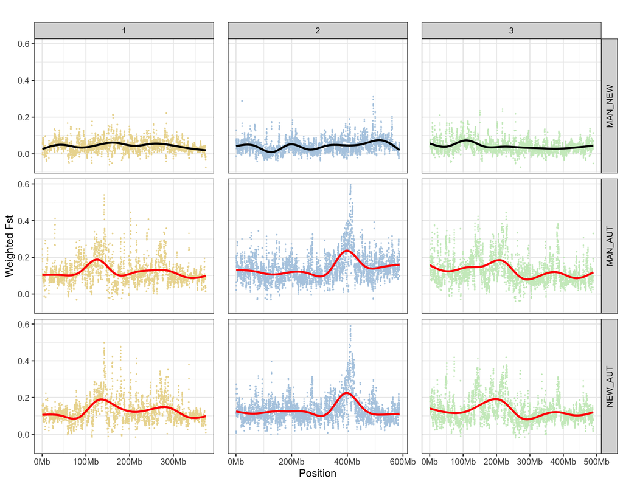

```r
# Calculate the middle position
combined_data$mid_pos <- with(combined_data, (BIN_START + BIN_END) / 2)

# Reorder the levels of the comparison factor
combined_data$comparison <- fct_relevel(combined_data$comparison, "MAN_NEW", "MAN_AUT", "NEW_AUT")

# Define a set of pastel colors for three chromosomes
pastel_colors <- c("#ebd99f", "#B3CDE3", "#CCEBC5")

# Create the facet plot
window_fst <-
  ggplot(combined_data,
         aes(
           x = mid_pos,
           y = WEIGHTED_FST,
           color = as.factor(CHROM)
         )) +
  geom_point(size = 0.1) +
  facet_grid(comparison ~ CHROM, scales = "free_x") +
  scale_x_continuous(labels = label_number(scale = 1e-6, suffix = "Mb")) +
  scale_color_manual(values = pastel_colors) +
  # Smooth line for MAN_NEW in black
  geom_smooth(
    data = subset(combined_data, comparison == "MAN_NEW"),
    aes(group = CHROM),
    se = FALSE,
    span = 0.3,
    color = "black"
  ) +
  # Smooth line for MAN_AUT in red
  geom_smooth(
    data = subset(combined_data, comparison == "MAN_AUT"),
    aes(group = CHROM),
    se = FALSE,
    span = 0.3,
    color = "red"
  ) +
  # Smooth line for NEW_AUT in red
  geom_smooth(
    data = subset(combined_data, comparison == "NEW_AUT"),
    aes(group = CHROM),
    se = FALSE,
    span = 0.3,
    color = "red"
  ) +
  theme_bw() +
  labs(x = "Position", y = "Weighted Fst", title = "") +
  theme(
    strip.text.x = element_text(angle = 0, hjust = .5),
    strip.text.y = element_text(angle = 90, hjust = .5),
    panel.spacing.x = unit(1.01, "lines"),
    legend.position = "none"
  )

window_fst
```

```r
output_path <- here("output", "fst", "figures", "pairwise_estimates_windows.pdf")
ggsave(output_path, window_fst, height = 7, width = 9, dpi = 300)
```

Chromosome 2 peaks seems interesting. We can find out what are the windows that have such ligh fst values

```r
# Lets find the windows for which the fst values are > 0.5
chr2 <- combined_data |>
  dplyr::filter(
    CHROM == "2"
  ) |>
  dplyr::filter(
    WEIGHTED_FST >= 0.5
  )

# View the results
print(chr2)
```

```
## # A tibble: 30 × 8
##    CHROM BIN_START   BIN_END N_VARIANTS WEIGHTED_FST MEAN_FST comparison mid_pos
##    <dbl>     <dbl>     <dbl>      <dbl>        <dbl>    <dbl> <fct>        <dbl>
##  1     2 410300001 411300000         26        0.560    0.395 NEW_AUT     4.11e8
##  2     2 410400001 411400000         30        0.542    0.376 NEW_AUT     4.11e8
##  3     2 410500001 411500000         33        0.520    0.365 NEW_AUT     4.11e8
##  4     2 410600001 411600000         36        0.567    0.407 NEW_AUT     4.11e8
##  5     2 410700001 411700000         35        0.574    0.427 NEW_AUT     4.11e8
##  6     2 410800001 411800000         37        0.591    0.429 NEW_AUT     4.11e8
##  7     2 410900001 411900000         42        0.589    0.424 NEW_AUT     4.11e8
##  8     2 411000001 412000000         45        0.569    0.408 NEW_AUT     4.12e8
##  9     2 411100001 412100000         42        0.591    0.440 NEW_AUT     4.12e8
## 10     2 411200001 412200000         36        0.540    0.405 NEW_AUT     4.12e8
## # ℹ 20 more rows
```

## 4. Sliding windows Fst estimates between the sexes

Clean env and memory

```r
# Remove all objects from the environment
rm(list = ls())

# Run the garbage collector to free up memory
gc()
```

```
##            used  (Mb) gc trigger  (Mb) limit (Mb) max used  (Mb)
## Ncells  6194404 330.9    9700114 518.1         NA  9336593 498.7
## Vcells 11146325  85.1   21770184 166.1      32768 21769864 166.1
```

We need to create a list of males and females for each population

```r
# Specify the path using the 'here' function
fam_file_path <- here("output", "fst", "new_aut.fam")

# Now, read the file using the path - using data.table library
fam_data2 <- fread(fam_file_path, header = FALSE)

# Rename columns for clarity
setnames(fam_data2, c("FID", "IID", "PID", "MID", "Sex", "Phenotype"))

head(fam_data2)
```

```
##      FID IID PID MID Sex Phenotype
## 1: AUT_M 384   0   0   1         2
## 2: AUT_M 385   0   0   1         2
## 3: AUT_M 386   0   0   1         2
## 4: AUT_M 387   0   0   1         2
## 5: AUT_M 388   0   0   1         2
## 6: AUT_M 389   0   0   1         2
```

We need the files to be in this format

```bash
head output/fst/NEW.txt
```

```
## NEW_413
## NEW_414
## NEW_415
## NEW_416
## NEW_417
## NEW_418
## NEW_419
## NEW_420
## NEW_421
## NEW_422
```

We can subset for each sex and create a file that we will use with vcftools

NEW males

```r
new_males <- fam_data2 |>
  dplyr::filter(FID == "NEW_M")

# Create ids to match what we have in the vcf
new_males$ID <- paste0(sub("_M", "_", new_males$FID), new_males$IID)


# Save it
write.table(new_males$ID, here("output", "fst","new_males_IDs.txt"), row.names = FALSE, col.names = FALSE, quote = FALSE)


head(new_males)
```

```
##      FID IID PID MID Sex Phenotype      ID
## 1: NEW_M 413   0   0   1         1 NEW_413
## 2: NEW_M 414   0   0   1         1 NEW_414
## 3: NEW_M 415   0   0   1         1 NEW_415
## 4: NEW_M 416   0   0   1         1 NEW_416
## 5: NEW_M 417   0   0   1         1 NEW_417
## 6: NEW_M 418   0   0   1         1 NEW_418
```

Check it

```bash
head output/fst/new_males_IDs.txt
```

```
## NEW_413
## NEW_414
## NEW_415
## NEW_416
## NEW_417
## NEW_418
## NEW_419
## NEW_420
## NEW_421
## NEW_422
```

Now do it for the remaining files

NEW females

```r
new_females <- fam_data2 |>
  dplyr::filter(FID == "NEW_F")

# Create ids to match what we have in the vcf
new_females$ID <- paste0(sub("_F", "_", new_females$FID), new_females$IID)


# Save it
write.table(new_females$ID, here("output", "fst","new_females_IDs.txt"), row.names = FALSE, col.names = FALSE, quote = FALSE)


head(new_females)
```

```
##      FID IID PID MID Sex Phenotype      ID
## 1: NEW_F 424   0   0   2         1 NEW_424
## 2: NEW_F 425   0   0   2         1 NEW_425
## 3: NEW_F 426   0   0   2         1 NEW_426
## 4: NEW_F 427   0   0   2         1 NEW_427
## 5: NEW_F 428   0   0   2         1 NEW_428
## 6: NEW_F 429   0   0   2         1 NEW_429
```

AUT males

```r
aut_males <- fam_data2 |>
  dplyr::filter(FID == "AUT_M")

# Create ids to match what we have in the vcf
aut_males$ID <- paste0(sub("_M", "_", aut_males$FID), aut_males$IID)


# Save it
write.table(aut_males$ID, here("output", "fst","aut_males_IDs.txt"), row.names = FALSE, col.names = FALSE, quote = FALSE)


head(aut_males)
```

```
##      FID IID PID MID Sex Phenotype      ID
## 1: AUT_M 384   0   0   1         2 AUT_384
## 2: AUT_M 385   0   0   1         2 AUT_385
## 3: AUT_M 386   0   0   1         2 AUT_386
## 4: AUT_M 387   0   0   1         2 AUT_387
## 5: AUT_M 388   0   0   1         2 AUT_388
## 6: AUT_M 389   0   0   1         2 AUT_389
```

AUT females

```r
aut_females <- fam_data2 |>
  dplyr::filter(FID == "AUT_F")

# Create ids to match what we have in the vcf
aut_females$ID <- paste0(sub("_F", "_", aut_females$FID), aut_females$IID)


# Save it
write.table(aut_females$ID, here("output", "fst","aut_females_IDs.txt"), row.names = FALSE, col.names = FALSE, quote = FALSE)


head(aut_females)
```

```
##      FID IID PID MID Sex Phenotype      ID
## 1: AUT_F 400   0   0   2         2 AUT_400
## 2: AUT_F 401   0   0   2         2 AUT_401
## 3: AUT_F 402   0   0   2         2 AUT_402
## 4: AUT_F 403   0   0   2         2 AUT_403
## 5: AUT_F 404   0   0   2         2 AUT_404
## 6: AUT_F 405   0   0   2         2 AUT_405
```

Now we can estimate fst with vcftools

NEW males vs NEW females

```bash
# Since we are using the SNP chip data, we can use a window of 1Mb and 100kb steps
vcftools --vcf output/fst/albo.vcf \
         --weir-fst-pop output/fst/new_males_IDs.txt \
         --weir-fst-pop output/fst/new_females_IDs.txt \
         --fst-window-size 1000000 \
         --fst-window-step 100000 \
         --out output/fst/new_sex
```

```
##
## VCFtools - 0.1.16
## (C) Adam Auton and Anthony Marcketta 2009
##
## Parameters as interpreted:
##  --vcf output/fst/albo.vcf
##  --fst-window-size 1000000
##  --fst-window-step 100000
##  --weir-fst-pop output/fst/new_males_IDs.txt
##  --weir-fst-pop output/fst/new_females_IDs.txt
##  --keep output/fst/new_males_IDs.txt
##  --keep output/fst/new_females_IDs.txt
##  --out output/fst/new_sex
##
## Warning: Expected at least 2 parts in INFO entry: ID=PR,Number=0,Type=Flag,Description="Provisional reference allele, may not be based on real reference genome">
## Keeping individuals in 'keep' list
## After filtering, kept 22 out of 60 Individuals
## Outputting Windowed Weir and Cockerham Fst estimates.
## Weir and Cockerham mean Fst estimate: 0.021818
## Weir and Cockerham weighted Fst estimate: 0.031432
## After filtering, kept 110353 out of a possible 110353 Sites
## Run Time = 3.00 seconds
```

AUT males vs AUT females

```bash
# Since we are using the SNP chip data, we can use a window of 1Mb and 100kb steps
vcftools --vcf output/fst/albo.vcf \
         --weir-fst-pop output/fst/aut_males_IDs.txt \
         --weir-fst-pop output/fst/aut_females_IDs.txt \
         --fst-window-size 1000000 \
         --fst-window-step 100000 \
         --out output/fst/aut_sex
```

```
##
## VCFtools - 0.1.16
## (C) Adam Auton and Anthony Marcketta 2009
##
## Parameters as interpreted:
##  --vcf output/fst/albo.vcf
##  --fst-window-size 1000000
##  --fst-window-step 100000
##  --weir-fst-pop output/fst/aut_males_IDs.txt
##  --weir-fst-pop output/fst/aut_females_IDs.txt
##  --keep output/fst/aut_males_IDs.txt
##  --keep output/fst/aut_females_IDs.txt
##  --out output/fst/aut_sex
##
## Warning: Expected at least 2 parts in INFO entry: ID=PR,Number=0,Type=Flag,Description="Provisional reference allele, may not be based on real reference genome">
## Keeping individuals in 'keep' list
## After filtering, kept 28 out of 60 Individuals
## Outputting Windowed Weir and Cockerham Fst estimates.
## Weir and Cockerham mean Fst estimate: 0.025784
## Weir and Cockerham weighted Fst estimate: 0.039617
## After filtering, kept 110353 out of a possible 110353 Sites
## Run Time = 2.00 seconds
```

NEW males vs AUT males

```bash
# Since we are using the SNP chip data, we can use a window of 1Mb and 100kb steps
vcftools --vcf output/fst/albo.vcf \
         --weir-fst-pop output/fst/new_males_IDs.txt \
         --weir-fst-pop output/fst/aut_males_IDs.txt \
         --fst-window-size 1000000 \
         --fst-window-step 100000 \
         --out output/fst/new_aut_males
```

```
##
## VCFtools - 0.1.16
## (C) Adam Auton and Anthony Marcketta 2009
##
## Parameters as interpreted:
##  --vcf output/fst/albo.vcf
##  --fst-window-size 1000000
##  --fst-window-step 100000
##  --weir-fst-pop output/fst/new_males_IDs.txt
##  --weir-fst-pop output/fst/aut_males_IDs.txt
##  --keep output/fst/new_males_IDs.txt
##  --keep output/fst/aut_males_IDs.txt
##  --out output/fst/new_aut_males
##
## Warning: Expected at least 2 parts in INFO entry: ID=PR,Number=0,Type=Flag,Description="Provisional reference allele, may not be based on real reference genome">
## Keeping individuals in 'keep' list
## After filtering, kept 26 out of 60 Individuals
## Outputting Windowed Weir and Cockerham Fst estimates.
## Weir and Cockerham mean Fst estimate: 0.12558
## Weir and Cockerham weighted Fst estimate: 0.16704
## After filtering, kept 110353 out of a possible 110353 Sites
## Run Time = 2.00 seconds
```

NEW females vs AUT females

```bash
# Since we are using the SNP chip data, we can use a window of 1Mb and 100kb steps
vcftools --vcf output/fst/albo.vcf \
         --weir-fst-pop output/fst/new_females_IDs.txt \
         --weir-fst-pop output/fst/aut_females_IDs.txt \
         --fst-window-size 1000000 \
         --fst-window-step 100000 \
         --out output/fst/new_aut_females
```

```
##
## VCFtools - 0.1.16
## (C) Adam Auton and Anthony Marcketta 2009
##
## Parameters as interpreted:
##  --vcf output/fst/albo.vcf
##  --fst-window-size 1000000
##  --fst-window-step 100000
##  --weir-fst-pop output/fst/new_females_IDs.txt
##  --weir-fst-pop output/fst/aut_females_IDs.txt
##  --keep output/fst/new_females_IDs.txt
##  --keep output/fst/aut_females_IDs.txt
##  --out output/fst/new_aut_females
##
## Warning: Expected at least 2 parts in INFO entry: ID=PR,Number=0,Type=Flag,Description="Provisional reference allele, may not be based on real reference genome">
## Keeping individuals in 'keep' list
## After filtering, kept 24 out of 60 Individuals
## Outputting Windowed Weir and Cockerham Fst estimates.
## Weir and Cockerham mean Fst estimate: 0.097099
## Weir and Cockerham weighted Fst estimate: 0.12133
## After filtering, kept 110353 out of a possible 110353 Sites
## Run Time = 3.00 seconds
```

Now we can import the results into R

NEW male vs female

```r
# Define the file path using here
file_path <- here("output", "fst", "new_sex.windowed.weir.fst")

# Import the file using read_delim
new_sex <- read_delim(file_path,
                       delim = "\t",    # Specify the tab delimiter
                       col_names = TRUE,
                      show_col_types = FALSE) # Indicates that the first row contains column names

# View the first few rows of the data
head(new_sex)
```

```
## # A tibble: 6 × 6
##   CHROM BIN_START BIN_END N_VARIANTS WEIGHTED_FST MEAN_FST
##   <dbl>     <dbl>   <dbl>      <dbl>        <dbl>    <dbl>
## 1     1         1 1000000         22      0.00698  0.00657
## 2     1    100001 1100000         21      0.00863  0.00819
## 3     1    200001 1200000         28      0.0149   0.0113
## 4     1    300001 1300000         35      0.0198   0.0159
## 5     1    400001 1400000         42      0.0248   0.0168
## 6     1    500001 1500000         39      0.0304   0.0197
```

AUT male vs female

```r
# Define the file path using here
file_path <- here("output", "fst", "aut_sex.windowed.weir.fst")

# Import the file using read_delim
aut_sex <- read_delim(file_path,
                       delim = "\t",    # Specify the tab delimiter
                       col_names = TRUE,
                      show_col_types = FALSE) # Indicates that the first row contains column names

# View the first few rows of the data
head(aut_sex)
```

```
## # A tibble: 6 × 6
##   CHROM BIN_START BIN_END N_VARIANTS WEIGHTED_FST MEAN_FST
##   <dbl>     <dbl>   <dbl>      <dbl>        <dbl>    <dbl>
## 1     1         1 1000000         19       0.0268  0.0152
## 2     1    100001 1100000         19       0.0268  0.0152
## 3     1    200001 1200000         24       0.0296  0.0150
## 4     1    300001 1300000         33       0.0212  0.00665
## 5     1    400001 1400000         37       0.0278  0.0123
## 6     1    500001 1500000         35       0.0282  0.0131
```

NEW males vs AUT males

```r
# Define the file path using here
file_path <- here("output", "fst", "new_aut_males.windowed.weir.fst")

# Import the file using read_delim
new_aut_males <- read_delim(file_path,
                       delim = "\t",    # Specify the tab delimiter
                       col_names = TRUE,
                      show_col_types = FALSE) # Indicates that the first row contains column names

# View the first few rows of the data
head(new_aut_males)
```

```
## # A tibble: 6 × 6
##   CHROM BIN_START BIN_END N_VARIANTS WEIGHTED_FST MEAN_FST
##   <dbl>     <dbl>   <dbl>      <dbl>        <dbl>    <dbl>
## 1     1         1 1000000         21        0.182    0.141
## 2     1    100001 1100000         20        0.179    0.135
## 3     1    200001 1200000         27        0.160    0.118
## 4     1    300001 1300000         36        0.159    0.116
## 5     1    400001 1400000         43        0.196    0.143
## 6     1    500001 1500000         40        0.171    0.125
```

NEW females vs AUT females

```r
# Define the file path using here
file_path <- here("output", "fst", "new_aut_females.windowed.weir.fst")


# Import the file using read_delim
new_aut_females <- read_delim(file_path,
                       delim = "\t",    # Specify the tab delimiter
                       col_names = TRUE,
                      show_col_types = FALSE) # Indicates that the first row contains column names

# View the first few rows of the data
head(new_aut_females)
```

```
## # A tibble: 6 × 6
##   CHROM BIN_START BIN_END N_VARIANTS WEIGHTED_FST MEAN_FST
##   <dbl>     <dbl>   <dbl>      <dbl>        <dbl>    <dbl>
## 1     1         1 1000000         21        0.158    0.127
## 2     1    100001 1100000         20        0.157    0.123
## 3     1    200001 1200000         26        0.149    0.112
## 4     1    300001 1300000         35        0.133    0.102
## 5     1    400001 1400000         43        0.151    0.120
## 6     1    500001 1500000         40        0.134    0.106
```

Combine the data

```r
# Add a new column 'comparison' to each tibble
new_sex$comparison <- "NEW_sex"
aut_sex$comparison <- "AUT_sex"
new_aut_males$comparison <- "Males"
new_aut_females$comparison <- "Females"

# Combine the tibbles using rbind
combined_data <- rbind(new_sex, aut_sex, new_aut_males, new_aut_females)

# View the first few rows of the combined data
head(combined_data)
```

```
## # A tibble: 6 × 7
##   CHROM BIN_START BIN_END N_VARIANTS WEIGHTED_FST MEAN_FST comparison
##   <dbl>     <dbl>   <dbl>      <dbl>        <dbl>    <dbl> <chr>
## 1     1         1 1000000         22      0.00698  0.00657 NEW_sex
## 2     1    100001 1100000         21      0.00863  0.00819 NEW_sex
## 3     1    200001 1200000         28      0.0149   0.0113  NEW_sex
## 4     1    300001 1300000         35      0.0198   0.0159  NEW_sex
## 5     1    400001 1400000         42      0.0248   0.0168  NEW_sex
## 6     1    500001 1500000         39      0.0304   0.0197  NEW_sex
```

Now we plot

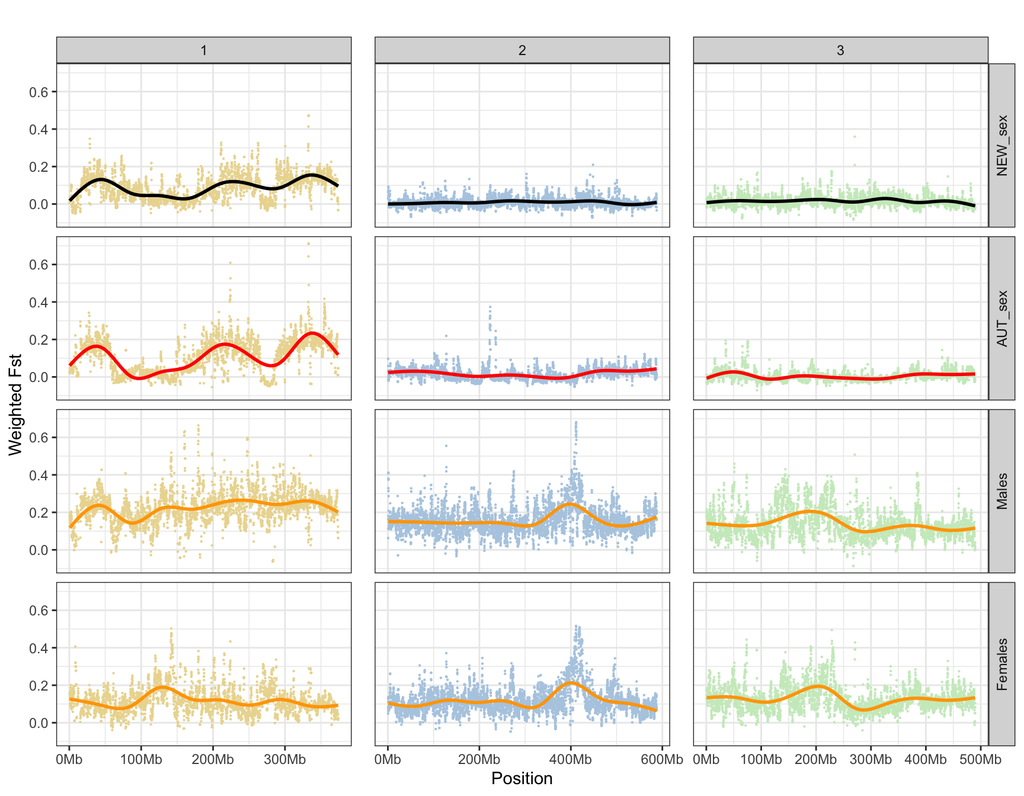

```r
# Calculate the middle position
combined_data$mid_pos <- with(combined_data, (BIN_START + BIN_END) / 2)

# Reorder the levels of the comparison factor
combined_data$comparison <- fct_relevel(combined_data$comparison, "NEW_sex", "AUT_sex", "Males", "Females")

# Define a set of pastel colors for three chromosomes
pastel_colors <- c("#ebd99f", "#B3CDE3", "#CCEBC5")

# Create the facet plot
window_fst <-
  ggplot(combined_data,
         aes(
           x = mid_pos,
           y = WEIGHTED_FST,
           color = as.factor(CHROM)
         )) +
  geom_point(size = 0.1) +
  facet_grid(comparison ~ CHROM, scales = "free_x") +
  scale_x_continuous(labels = label_number(scale = 1e-6, suffix = "Mb")) +
  scale_color_manual(values = pastel_colors) +
  geom_smooth(
    data = subset(combined_data, comparison == "NEW_sex"),
    aes(group = CHROM),
    se = FALSE,
    span = 0.3,
    color = "black"
  ) +
  geom_smooth(
    data = subset(combined_data, comparison == "AUT_sex"),
    aes(group = CHROM),
    se = FALSE,
    span = 0.3,
    color = "red"
  ) +
  geom_smooth(
    data = subset(combined_data, comparison == "Males"),
    aes(group = CHROM),
    se = FALSE,
    span = 0.3,
    color = "orange"
  ) +
  geom_smooth(
    data = subset(combined_data, comparison == "Females"),
    aes(group = CHROM),
    se = FALSE,
    span = 0.3,
    color = "orange"
  ) +
  theme_bw() +
  labs(x = "Position", y = "Weighted Fst", title = "") +
  theme(
    strip.text.x = element_text(angle = 0, hjust = .5),
    strip.text.y = element_text(angle = 90, hjust = .5),
    panel.spacing.x = unit(1.01, "lines"),
    legend.position = "none"
  )

window_fst
```

```r
output_path <- here("output", "fst", "figures", "sex_pairwise_estimates_windows.pdf")
ggsave(output_path, window_fst, height = 7, width = 9, dpi = 300)
```

## 5. Check windows of interest

Chromosome 2 peaks seems interesting. We can find out what are the windows that have such ligh fst values

```r
# Lets find the windows for which the fst values are > 0.5
chr2 <- combined_data |>
  dplyr::filter(
    CHROM == "2"
  ) |>
  dplyr::filter(
    WEIGHTED_FST >= 0.5
  )

# View the results
print(chr2)
```

```
## # A tibble: 23 × 8
##    CHROM BIN_START   BIN_END N_VARIANTS WEIGHTED_FST MEAN_FST comparison mid_pos
##    <dbl>     <dbl>     <dbl>      <dbl>        <dbl>    <dbl> <fct>        <dbl>
##  1     2 127200001 128200000          3        0.555    0.316 Males       1.28e8
##  2     2 407500001 408500000          9        0.519    0.415 Males       4.08e8
##  3     2 410200001 411200000         24        0.564    0.357 Males       4.11e8
##  4     2 410300001 411300000         25        0.650    0.450 Males       4.11e8
##  5     2 410400001 411400000         29        0.636    0.426 Males       4.11e8
##  6     2 410500001 411500000         32        0.613    0.412 Males       4.11e8
##  7     2 410600001 411600000         34        0.660    0.471 Males       4.11e8
##  8     2 410700001 411700000         34        0.660    0.470 Males       4.11e8
##  9     2 410800001 411800000         36        0.673    0.470 Males       4.11e8
## 10     2 410900001 411900000         41        0.673    0.455 Males       4.11e8
## # ℹ 13 more rows
```

Find the overlapping windows between males and females

```r
# Find rows with the same BIN_START but different comparison values
overlapping_starts <- chr2 %>%
  group_by(BIN_START) %>%
  filter(n() > 1 & n_distinct(comparison) > 1) %>%
  ungroup()

# View the results
print(overlapping_starts)
```

```
## # A tibble: 6 × 8
##   CHROM BIN_START   BIN_END N_VARIANTS WEIGHTED_FST MEAN_FST comparison  mid_pos
##   <dbl>     <dbl>     <dbl>      <dbl>        <dbl>    <dbl> <fct>         <dbl>
## 1     2 410800001 411800000         36        0.673    0.470 Males        4.11e8
## 2     2 410900001 411900000         41        0.673    0.455 Males        4.11e8
## 3     2 411100001 412100000         41        0.681    0.476 Males        4.12e8
## 4     2 410800001 411800000         35        0.516    0.410 Females      4.11e8
## 5     2 410900001 411900000         40        0.515    0.411 Females      4.11e8
## 6     2 411100001 412100000         40        0.511    0.420 Females      4.12e8
```

We have 3 windows. Starts on 410800001 and end on 412100000

```r
# Window size in kb - each window is 100kb
(412100000 - 410800001) / 1000
```

```
## [1] 1299.999
```

Now we can import the bin file that has the chromosomal scale and filter out by position

```r
# Import the function
source(
  here(
    "scripts", "analysis", "import_bim.R")
)

# Import the data
snps <- import_bim(here("output", "quality_control", "file7.bim"))

# Check it
head(snps)
```

```
## # A tibble: 6 × 6
##   Scaffold SNP             Cm Position Allele1 Allele2
##   <chr>    <chr>        <int>    <dbl> <chr>   <chr>
## 1 1        AX-581444870     0    97856 C       T
## 2 1        AX-583035083     0   305518 A       G
## 3 1        AX-583035102     0   308124 A       G
## 4 1        AX-583033342     0   315059 C       G
## 5 1        AX-583035163     0   315386 A       G
## 6 1        AX-583033356     0   315674 C       T
```

Now we can select the window and get the SNP ids

```r
# Filter the data for Scaffold 2 and Position range
window_snps <- snps %>%
  filter(Scaffold == "2", Position >= 410800001, Position <= 412100000)

# View the results
print(window_snps) # 46 SNPs
```

```
## # A tibble: 46 × 6
##    Scaffold SNP             Cm  Position Allele1 Allele2
##    <chr>    <chr>        <int>     <dbl> <chr>   <chr>
##  1 2        AX-579630382     0 411040898 C       T
##  2 2        AX-579630409     0 411053076 G       C
##  3 2        AX-579630426     0 411076185 G       A
##  4 2        AX-579630432     0 411095416 T       G
##  5 2        AX-579630434     0 411100836 G       C
##  6 2        AX-579630438     0 411101050 T       G
##  7 2        AX-579630465     0 411118768 T       C
##  8 2        AX-579630489     0 411120151 T       C
##  9 2        AX-579630502     0 411120383 A       C
## 10 2        AX-579632017     0 411129367 T       C
## # ℹ 36 more rows
```

Now we can filter out it from our gene data

Import the data

```r
snps_genes_chr <- readRDS(here("output", "ldna", "snps_genes_chr.rds"))
head(snps_genes_chr)
```

```
## # A tibble: 6 × 8
##   SNP          Chromosome Position_chr Scaffold Position Gene_ID    Start    End
##   <chr>        <chr>             <dbl> <chr>       <dbl> <chr>      <dbl>  <dbl>
## 1 AX-581444870 1                 97856 1.1         97856 LOC10939…  64508 102530
## 2 AX-583033342 1                315059 1.1        315059 LOC10943… 310594 316608
## 3 AX-583035163 1                315386 1.1        315386 LOC10943… 310594 316608
## 4 AX-583033356 1                315674 1.1        315674 LOC10943… 310594 316608
## 5 AX-583035257 1                442875 1.10        91677 LOC10940…  66918 192829
## 6 AX-583035268 1                462944 1.10       111746 LOC10940…  66918 192829
```

The expression data

```r
gene_expression <- read_delim(here("data", "files","MANvsAUTO_sig_mRNAs.csv"), delim = ",", col_names = TRUE, show_col_types = FALSE) |>
  dplyr::select(
    gene,log2FoldChange
  ) |>
  dplyr::rename(
    Gene_ID = gene
  )
head(gene_expression)
```

```
## # A tibble: 6 × 2
##   Gene_ID      log2FoldChange
##   <chr>                 <dbl>
## 1 LOC115262812         -10.5
## 2 LOC109401291          -9.19
## 3 LOC109397830           8.73
## 4 LOC115264022           8.56
## 5 LOC115260314           8.51
## 6 LOC115258723           8.39
```

First we can find how many genes we have for this window

```r
fst_cluster_chr2 <- snps_genes_chr[snps_genes_chr$SNP %in% window_snps$SNP, ]

# How many genes in the scaffolds
length(unique(fst_cluster_chr2$Gene_ID))
```

```
## [1] 1
```

```r
# How many SNPs
length(unique(fst_cluster_chr2$SNP))
```

```
## [1] 20
```

Check it

```r
fst_cluster_chr2
```

```
## # A tibble: 20 × 8
##    SNP          Chromosome Position_chr Scaffold Position Gene_ID   Start    End
##    <chr>        <chr>             <dbl> <chr>       <dbl> <chr>     <dbl>  <dbl>
##  1 AX-579630382 2             411040898 2.42      2888381 LOC1094… 2.77e6 3.13e6
##  2 AX-579630409 2             411053076 2.42      2900559 LOC1094… 2.77e6 3.13e6
##  3 AX-579630426 2             411076185 2.42      2923668 LOC1094… 2.77e6 3.13e6
##  4 AX-579630432 2             411095416 2.42      2942899 LOC1094… 2.77e6 3.13e6
##  5 AX-579630434 2             411100836 2.42      2948319 LOC1094… 2.77e6 3.13e6
##  6 AX-579630438 2             411101050 2.42      2948533 LOC1094… 2.77e6 3.13e6
##  7 AX-579630465 2             411118768 2.42      2966251 LOC1094… 2.77e6 3.13e6
##  8 AX-579630489 2             411120151 2.42      2967634 LOC1094… 2.77e6 3.13e6
##  9 AX-579630502 2             411120383 2.42      2967866 LOC1094… 2.77e6 3.13e6
## 10 AX-579632017 2             411129367 2.42      2976850 LOC1094… 2.77e6 3.13e6
## 11 AX-579632033 2             411129637 2.42      2977120 LOC1094… 2.77e6 3.13e6
## 12 AX-579630663 2             411156954 2.42      3004437 LOC1094… 2.77e6 3.13e6
## 13 AX-579630698 2             411157516 2.42      3004999 LOC1094… 2.77e6 3.13e6
## 14 AX-579632196 2             411163842 2.42      3011325 LOC1094… 2.77e6 3.13e6
## 15 AX-579632353 2             411204548 2.42      3052031 LOC1094… 2.77e6 3.13e6
## 16 AX-579630892 2             411205467 2.42      3052950 LOC1094… 2.77e6 3.13e6
## 17 AX-579632415 2             411217508 2.42      3064991 LOC1094… 2.77e6 3.13e6
## 18 AX-579632471 2             411234189 2.42      3081672 LOC1094… 2.77e6 3.13e6
## 19 AX-579632599 2             411284443 2.42      3131926 LOC1094… 2.77e6 3.13e6
## 20 AX-579631153 2             411284926 2.42      3132409 LOC1094… 2.77e6 3.13e6
```

Is this gene also DE?

```r
fst_cluster_chr2_de <- fst_cluster_chr2[fst_cluster_chr2$Gene_ID %in% gene_expression$Gene_ID, ]
# no it is not DE expressed
```

Now we can check if any SNP from the LD cluster 14 is on this Fst peak

```r
aut_ch2 <- readRDS(here("output", "ldna", "pop", "chr2", "AUT_clusters_snps.rds"))
str(aut_ch2$`3139_0.78`)
```

```
##  chr [1:566] "AX-579450486" "AX-579456609" "AX-579459157" "AX-579459504" ...
```

```r
# We have 566 SNPs on this cluster
```

```r
fst_ld_cluster <- fst_cluster_chr2[fst_cluster_chr2$SNP %in% aut_ch2$`3139_0.78`, ]
# none of them
```

```r
# Filter the data for Scaffold 2 and Position range
scaffold_242 <- snps_genes_chr %>%
  filter(Scaffold == "2.42")

# View the results
length(unique(scaffold_242$Gene_ID)) # 92 genes on this scaffold
```

```
## [1] 92
```

Are any of these 92 genes DE?

```r
fst_ld_de_genes <- scaffold_242[scaffold_242$Gene_ID %in% gene_expression$Gene_ID, ]
head(fst_ld_de_genes)
```

```
## # A tibble: 1 × 8
##   SNP          Chromosome Position_chr Scaffold Position Gene_ID    Start    End
##   <chr>        <chr>             <dbl> <chr>       <dbl> <chr>      <dbl>  <dbl>
## 1 AX-579624053 2             409015071 2.42       862554 LOC11526… 839135 863407
```